# U1-Predicting-response-times-of-the-Paris-Fire_Brigade-vehicles

### Y0

```r
library(h2o)
h2o.init()
```

[output not shown]

```r
h2o.train <- as.h2o(data.fe.reduced.0)
h2o.test <- as.h2o(x_test.reduced)
h2o.model <-  h2o.deeplearning(x=setdiff(names(data.fe.reduced.0),c("delta.selection.departure")),y ="delta.selection.departure",training_frame = h2o.train,standardize = TRUE,hidden = c(100, 100,100),rate = 0.01,epochs = 1000,seed = 1234)
h2o.prediction.y0 <- as.data.frame(h2o.predict(h2o.model, h2o.test))
h2o.prediction.y0 %>% head
```

```
##    predict
## 1 263.7359
## 2 112.7732
## 3 130.5915
## 4 166.9196
## 5 131.5314
## 6 165.8459
```

### Y1

```r
h2o.train.1 <- as.h2o(data.fe.reduced.1)
h2o.model <-  h2o.deeplearning(x=setdiff(names(data.fe.reduced.1),c("delta.departure.presentation")),y ="delta.departure.presentation",training_frame = h2o.train.1,standardize = TRUE,hidden = c(100, 100,100),rate = 0.01,epochs = 1000,seed = 1234)
h2o.prediction.y1 <- as.data.frame(h2o.predict(h2o.model, h2o.test))
```

### Compute global

```r
h20_ys=h2o.prediction.y0+h2o.prediction.y1
pred_final=data.frame(h2o.prediction.y0,h2o.prediction.y1,h20_ys)
```

```r
pred_final %>% head
```

```
##    predict predict.1 predict.2
## 1 263.7359  346.5793  610.3153
## 2 112.7732  413.5207  526.2940
## 3 130.5915  246.1286  376.7201
## 4 166.9196  283.9014  450.8210
## 5 131.5314  348.4830  480.0144
## 6 165.8459  285.0595  450.9053
```

```r
pred_final$id<-x_test$emergency.vehicle.selection
```

Change columns order

```r
pred_final <- pred_final[, c(4, 1, 2, 3)]
```

Retrieve order from original

```r
pred_final %>% head
```

```
##        id  predict predict.1 predict.2
## 1 4715068 263.7359  346.5793  610.3153
## 2 4714816 112.7732  413.5207  526.2940
## 3 4713710 130.5915  246.1286  376.7201
## 4 4713748 166.9196  283.9014  450.8210
## 5 4713778 131.5314  348.4830  480.0144
## 6 4713812 165.8459  285.0595  450.9053
```

```r
pred_final %>% head
```

```
##        id  predict predict.1 predict.2
## 1 4715068 263.7359  346.5793  610.3153
## 2 4714816 112.7732  413.5207  526.2940
## 3 4713710 130.5915  246.1286  376.7201
## 4 4713748 166.9196  283.9014  450.8210
## 5 4713778 131.5314  348.4830  480.0144
## 6 4713812 165.8459  285.0595  450.9053
```

```r
id_order %>% head
```

```
##   x_test.emergency.vehicle.selection rank rank rank
## 1                            5271704    1    1    1
## 2                            5092931    2    2    2
## 3                            5153756    3    3    3
## 4                            5355572    4    4    4
## 5                            5178915    5    5    5
## 6                            5206885    6    6    6
```

```r
len <- dim(id_order)[1]
id_order <- cbind(id_order, rank=1:len)
```

```r
id_order %>% head
```

```
##   x_test.emergency.vehicle.selection rank rank rank rank
## 1                            5271704    1    1    1    1
## 2                            5092931    2    2    2    2
## 3                            5153756    3    3    3    3
## 4                            5355572    4    4    4    4
## 5                            5178915    5    5    5    5
## 6                            5206885    6    6    6    6
```

```r
y_final=merge(pred_final,id_order, by.x = 'id', by.y = 'x_test.emergency.vehicle.selection', all = FALSE)
```

```r
y_final %>% head
```

```
##        id  predict predict.1 predict.2  rank rank.1 rank.2 rank.3
## 1 4713710 130.5915  246.1286  376.7201 14082  14082  14082  14082
## 2 4713748 166.9196  283.9014  450.8210 25965  25965  25965  25965
## 3 4713778 131.5314  348.4830  480.0144 14465  14465  14465  14465
## 4 4713812 165.8459  285.0595  450.9053 79530  79530  79530  79530
## 5 4713821 151.7333  572.5734  724.3068 47824  47824  47824  47824
## 6 4713863 124.6063  148.1335  272.7398  2072   2072   2072   2072
```

```r
y_final=y_final[order(y_final[,'rank']),]
y_final %>% head
```

```
##            id  predict predict.1 predict.2 rank rank.1 rank.2 rank.3
## 77897 5271704 112.6084  411.4832  524.0916    1      1      1      1
## 59352 5092931 120.0579  409.7404  529.7983    2      2      2      2
## 68483 5153756 122.7251  238.9925  361.7176    3      3      3      3
## 91242 5355572 247.5476  221.9852  469.5328    4      4      4      4
## 72358 5178915 140.4392  264.6780  405.1172    5      5      5      5
## 77062 5206885 130.5567  258.7095  389.2663    6      6      6      6
```

```r
y_final %>% setDT
y_final=y_final[,-c("rank.1")]
```

```r
y_final %>% head
```

```
##         id  predict predict.1 predict.2 rank rank.2 rank.3
## 1: 5271704 112.6084  411.4832  524.0916    1      1      1
## 2: 5092931 120.0579  409.7404  529.7983    2      2      2
## 3: 5153756 122.7251  238.9925  361.7176    3      3      3
## 4: 5355572 247.5476  221.9852  469.5328    4      4      4
## 5: 5178915 140.4392  264.6780  405.1172    5      5      5
## 6: 5206885 130.5567  258.7095  389.2663    6      6      6
```

```r
sum(is.na(y_final))
```

```
## [1] 0
```

```r
which(is.na(y_final))
```

```
## integer(0)
```

```r
y_final[is.na(y_final)] <- 0
```

Write csv file. Go to pyhton script for generate good csv.

```r
fwrite(y_final, "y_test.csv",sep=",")
```

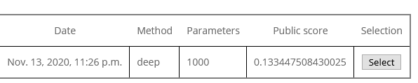

R2

## 11. To Follow …

What could be done in order to increase our R2 ?

- Increase Feature Buidling: add supp files from data Coordinate : lot of thing to do - Direction, km from Paris Center (traffic issue) Mean speed / vehicule type Mean speed / rescue center Holidays or not (traffic issue) We have removed GPS data because of NA but can be important ? Vehicule type
- Add a real CV and model selection part : Once the best model identified,
- go to hyperparameters tunning.

## Acknowledgements and references

The following is a list of helpful contributor.

- Professor Nadine Galy- Econometrics and Statitical Models [U1 -MSc AI and BA- TBS] - 2020
- Github https://github.com/quachn/X_PFB
- Medium https://medium.com/crim/predicting-the-response-times-of-firefighters-using-data-science-da79f6965f93
- Kaggle https://www.kaggle.com/headsortails/nyc-taxi-eda-update-the-fast-the-curious
- Stack Overflow community

Thank you for reading !